# Using Data Mining Techniques into Real Estates Industry

#### On real estates dataframe

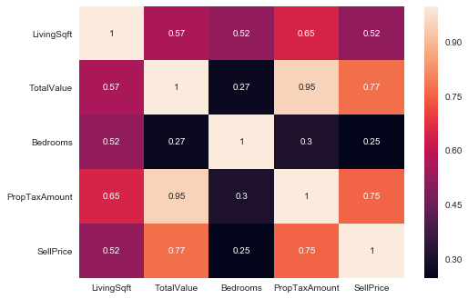

```python
corrMatrix = df_houses[columns_for_outliers_detection].corr()
sns.heatmap(corrMatrix, annot=True)
plt.show()
```

I am going to choose two independent varibale which are less corelated, and if possible not categorical, as 'Bedrooms'.

```python
clf = LocalOutlierFactor(contamination=0.1)
y_pred = clf.fit_predict(df_houses[['LivingSqft', 'SellPrice']])
outliers_pred = [1 if y == -1 else 0 for y in y_pred]
X_scores = clf.negative_outlier_factor_
```

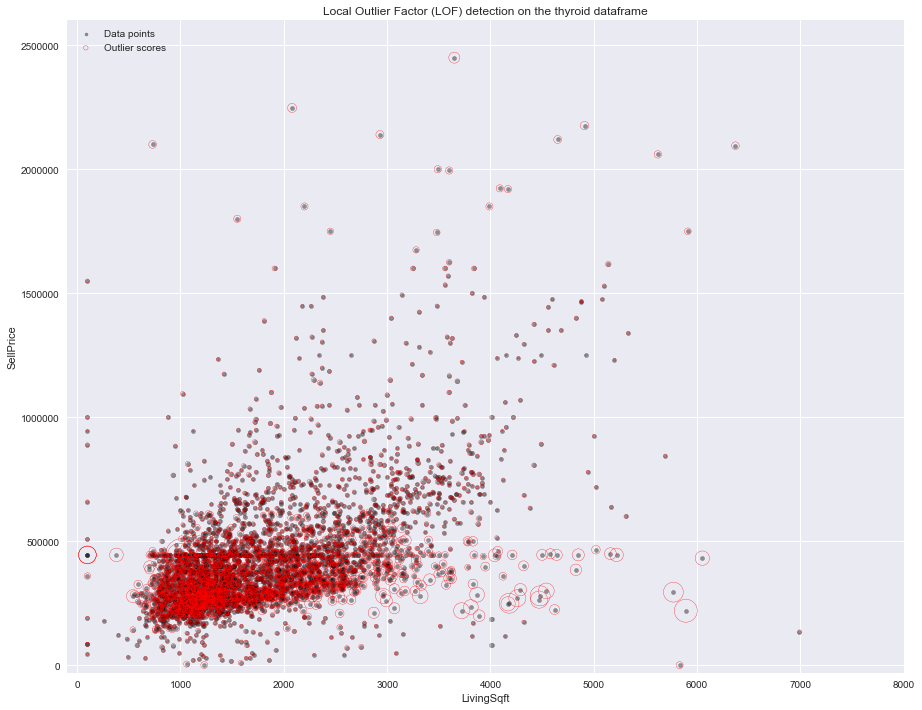

```python
fig = plt.figure(figsize=(15,12))

plt.title("Local Outlier Factor (LOF) detection on the thyroid dataframe")
plt.scatter(df_houses['LivingSqft'], df_houses['SellPrice'], color='k', s=18, alpha=0.4, label='Data points')

# plot circles with radius proportional to the outlier scores
radius = (X_scores.max() - X_scores) / (X_scores.max() - X_scores.min())
plt.scatter(df_houses['LivingSqft'], df_houses['SellPrice'], s=1000 * radius, edgecolors='r',
            facecolors='none', label='Outlier scores')

plt.axis('tight')
plt.xlim((-100, 8000))
plt.ylim((-30000, 0.26e7))
plt.xlabel('LivingSqft')
plt.ylabel('SellPrice')

legend = plt.legend(loc='upper left')
legend.legendHandles[0]._sizes = [10]
legend.legendHandles[1]._sizes = [20]
plt.show()
```

### Outliers detection using decession trees: Isolation Forest

The **IsolationForest** ‘isolates’ observations by randomly selecting a feature and then randomly selecting a split value between the maximum and minimum values of the selected feature.

Since recursive partitioning can be represented by a tree structure, the number of splittings required to isolate a sample is equivalent to the path length from the root node to the terminating node.

This path length, averaged over a forest of such random trees, is a measure of normality and our decision function.

Random partitioning produces noticeable shorter paths for anomalies. Hence, when a forest of random trees collectively produce shorter path lengths for particular samples, they are highly likely to be anomalies.

#### On labeled dataframe

##### Isolation Forest using all of the independent variables

```python
from sklearn.ensemble import IsolationForest

def get_incorrectly_classif_perc_isol_forest_givem_min_samples(df, max_samples, features, labeled=True):
    clf = IsolationForest(max_samples=max_samples, random_state=0)

    y_pred = clf.fit_predict(df[features]) # 1 for inliers, -1 for outliers
    outliers_pred = [1 if y == -1 else 0 for y in y_pred]
    if labeled:
        return incorrecty_detected_percentage(outliers_pred), Counter(outliers_pred), outliers_pred, clf
    else:
        return Counter(outliers_pred), outliers_pred, clf

sorted({i: get_incorrectly_classif_perc_isol_forest_givem_min_samples(df_thyroid, i, features)[:2] for i in [1, 3, 4, 5, 6, 10, 100]}.items(),
       key=lambda kv: kv[1])
```

```
[(4, (1.378579003181336, Counter({0: 3713, 1: 59}))),
 (1, (2.4655355249204667, Counter({0: 3772}))),
 (3, (2.4655355249204667, Counter({0: 3772}))),
 (5, (7.370095440084835, Counter({0: 3409, 1: 363}))),
 (100, (11.346765641569458, Counter({0: 3257, 1: 515}))),
 (6, (15.217391304347828, Counter({0: 3105, 1: 667}))),
 (10, (28.04878048780488, Counter({0: 2621, 1: 1151})))]
```

##### Isolation Forest using all only of the independent variables: 'Feature0' and 'Feature3'

```python
sorted({i: get_incorrectly_classif_perc_isol_forest_givem_min_samples(df_thyroid, i, ['Feature0', 'Feature3'])[:2]
        for i in [1, 3, 4, 5, 6, 10, 100]}.items(),
       key=lambda kv: kv[1])
```

```
[(1, (2.4655355249204667, Counter({0: 3772}))),
 (3, (2.4655355249204667, Counter({0: 3772}))),
 (4, (5.249204665959703, Counter({0: 3655, 1: 117}))),
 (5, (21.818663838812302, Counter({0: 2982, 1: 790}))),
 (100, (23.09119830328738, Counter({0: 2826, 1: 946}))),
 (6, (37.089077412513255, Counter({0: 2306, 1: 1466}))),
 (10, (47.50795334040297, Counter({1: 1881, 0: 1891})))]
```

```
Isolation forest  -----------------  5.249204665959703% from the samples were incorrectly detected

_______________ Detection Report _______________

               precision    recall  f1-score   support

           0       0.98      0.97      0.97      3679
           1       0.05      0.06      0.06        93

    accuracy                           0.95      3772
   macro avg       0.51      0.52      0.52      3772
weighted avg       0.95      0.95      0.95      3772

________________________________________________________________________________________________
```

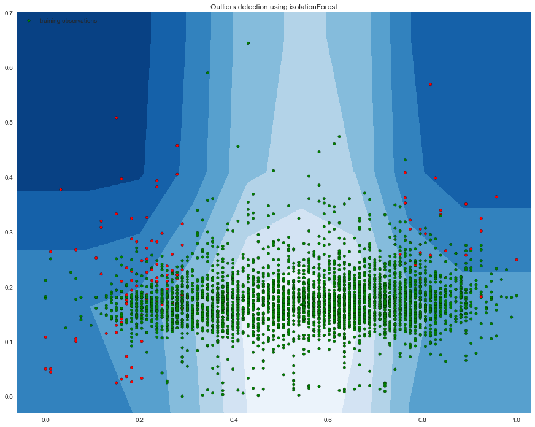

```python
_, _, outliers_pred, clf = get_incorrectly_classif_perc_isol_forest_givem_min_samples(df_thyroid, 4, ['Feature0', 'Feature3'])
get_detection_results_on_labeled_df('Isolation forest', outliers_pred, False)

fig = plt.figure(figsize=(15,12))

# plot the line, the samples, and the nearest vectors to the plane
xx, yy = np.meshgrid(np.linspace(-3, 2.6, 50), np.linspace(-4, 8, 50))
Z = clf.decision_function(np.c_[xx.ravel(), yy.ravel()])
Z = Z.reshape(xx.shape)

plt.title("Outliers detection using isolationForest")
plt.contourf(xx, yy, Z, cmap=plt.cm.Blues_r)

scatter_points = plt.scatter(df_thyroid['Feature0'], df_thyroid['Feature5'],
                 c=['red' if i==1 else 'green' for i in outliers_pred],
                 s=20, edgecolor='k')
plt.axis('tight')
plt.xlim((-0.06, 1.03))
plt.ylim((-0.03, 0.7))
plt.legend([scatter_points], ["training observations"], loc="upper left")
plt.show()
```

#### On real estates dataframe

Since the dataset is not labeled I am going to choose the best value for the max_samples parameter by taking into count the percentage of contamination, so that not too much samples to be detected as outliers. I am going to use firstly the entires set of features, and after that a set of 2 variables from those 5 mentioned in the univariate detection section.

##### Isolation forest using the entire set of predictors

```python
{i: get_incorrectly_classif_perc_isol_forest_givem_min_samples(df_houses, i, list(df_houses), False)[:1]
 for i in [1, 3, 4, 5, 6, 10, 100]}
```

```
{1: (Counter({0: 3802}),),
 3: (Counter({0: 3802}),),
 4: (Counter({0: 3616, 1: 186}),),
 5: (Counter({0: 3078, 1: 724}),),
 6: (Counter({1: 1491, 0: 2311}),),
 10: (Counter({1: 1743, 0: 2059}),),
 100: (Counter({1: 733, 0: 3069}),)}
```

I am going to choose the max_samples to be 4.

##### Isolation forest using combinations of 2 independent variables

```python
{i: get_incorrectly_classif_perc_isol_forest_givem_min_samples(df_houses, i, ['LivingSqft', 'SellPrice'], False)[:1]
 for i in [1, 3, 4, 5, 6, 10, 100]}
```

```
{1: (Counter({0: 3802}),),
 3: (Counter({0: 3802}),),
 4: (Counter({0: 3621, 1: 181}),),
 5: (Counter({0: 3188, 1: 614}),),
 6: (Counter({0: 2841, 1: 961}),),
 10: (Counter({1: 1372, 0: 2430}),),
 100: (Counter({1: 707, 0: 3095}),)}
```

I am going to choose max_samples=4.

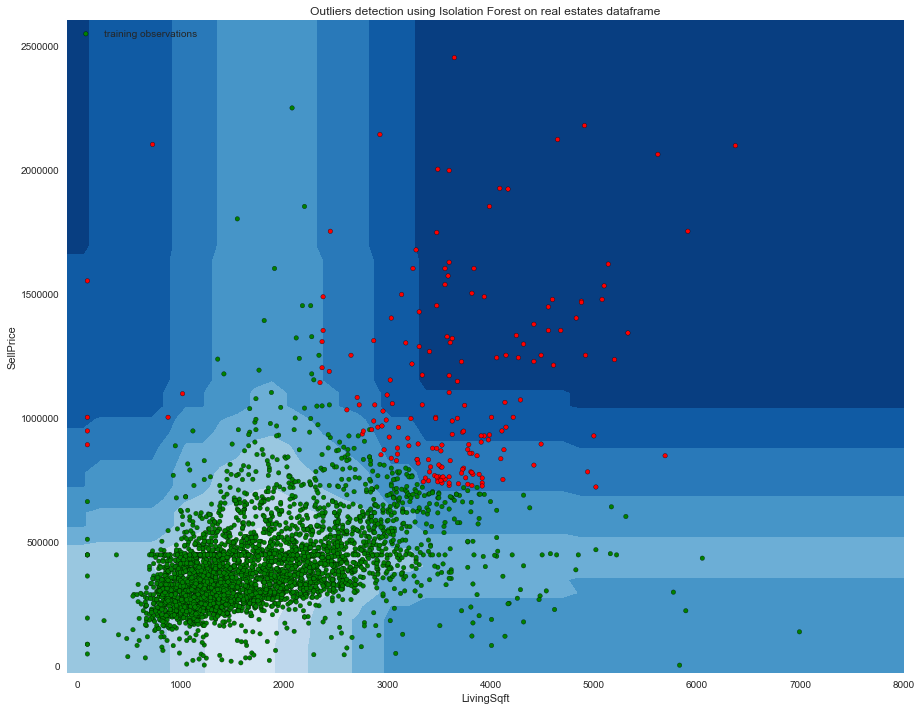

```python
_, outliers_pred, clf = get_incorrectly_classif_perc_isol_forest_givem_min_samples(df_houses, i,
                                                                                   ['LivingSqft', 'SellPrice'], False)
fig = plt.figure(figsize=(15,12))

# plot the line, the samples, and the nearest vectors to the plane
xx, yy = np.meshgrid(np.linspace(-100, 8000, 50), np.linspace(-30000, 0.26e7, 50))
Z = clf.decision_function(np.c_[xx.ravel(), yy.ravel()])
Z = Z.reshape(xx.shape)

plt.title("Outliers detection using Isolation Forest on real estates dataframe")
plt.contourf(xx, yy, Z, cmap=plt.cm.Blues_r)

scatter_points = plt.scatter(df_houses['LivingSqft'], df_houses['SellPrice'],
                 c=['red' if i==1 else 'green' for i in outliers_pred],
                 s=20, edgecolor='k')
plt.axis('tight')
plt.xlim((-100, 8000))
plt.ylim((-30000, 0.26e7))
plt.xlabel('LivingSqft')
plt.ylabel('SellPrice')
plt.legend([scatter_points], ["training observations"], loc="upper left")
plt.show()
```

### Results centralization on the labeled dataframe

```python
pd.DataFrame({'Method': ['1.5IQR rule', 'Mahalanobis distance',
                         'Local outlier factor', 'Local outlier factor',
                         'Isolation Forest','Isolation Forest'],
            'All predictors': ['only Feature0', 'Yes', 'Yes',
                               'Feature0 + Feature3', 'Yes', 'Feature0 + Feature3'],
            'Incorrectly detected': ['2.4655355249204667%', '5.090137857900318%',
                                     '3.3669141039236483%', '2.99575821845175%',
                                     '1.378579003181336%', '5.249204665959703%'],
            'Config': ['-', 'threshhold 0.6', 'n_neighbors=100, contamination=0.03',
                       'n_neighbors=100, contamination=0.03',
                      'max_samples=4', 'max_samples=4']
             }).sort_values(by=['Incorrectly detected'],ascending=True)
```

|  | Method | All predictors | Incorrectly detected | Config |
| --- | --- | --- | --- | --- |
| 4 | Isolation Forest | Yes | 1.378579003181336% | max_samples=4 |
| 0 | 1.5IQR rule | only Feature0 | 2.4655355249204667% | - |
| 3 | Local outlier factor | Feature0 + Feature3 | 2.99575821845175% | n_neighbors=100, contamination=0.03 |
| 2 | Local outlier factor | Yes | 3.3669141039236483% | n_neighbors=100, contamination=0.03 |
| 1 | Mahalanobis distance | Yes | 5.090137857900318% | threshhold 0.6 |
| 5 | Isolation Forest | Feature0 + Feature3 | 5.249204665959703% | max_samples=4 |

### Another methods for anomaly detection

Among other methods of identifying outliers it's worth be specified the following:

- **projection methods: Stahel-Donoho extensions for asymmetrical distributions**
- **autoencoders**: https://towardsdatascience.com/anomaly-detection-with-autoencoder-b4cdce4866a6

## References

1. **Thyroid dataset**: http://odds.cs.stonybrook.edu/thyroid-disease-dataset/
2. **Detecting outliers using the Mahalanobis distance with PCA in Python**: https://nirpyresearch.com/detecting-outliers-using-mahalanobis-distance-pca-python/
3. **LOF**: https://scikit-learn.org/stable/auto_examples/neighbors/plot_lof_outlier_detection.html
4. **Isolation Forest**: https://scikit-learn.org/stable/auto_examples/ensemble/plot_isolation_forest.html